# Using functions with Data

Naomi Tague

January, 2022

# Questions

- sampling_example.Rmd
- error_checking.Rmd

# Steps for running your model over multiple inputs

1. design a data structure to store results: sometimes this is automatic but not always
2. generate the input data
3. apply to the model

# Consider our function that estimates the power required to keep a car moving at a given speed

Code

```r
#' Power Required by Speed
#'
#' This function determines the power required to keep a vehicle moving at
#' a given speed
#' @param cdrag coefficient due to drag default=0.3
#' @param crolling coefficient due to rolling/friction default=0.015
#' @param v vehicle speed (m/2)
#' @param m vehicle mass (kg)
#' @param A area of front of vehicle (m2)
#' @param g acceleration due to gravity (m/s) default=9.8
#' @param pair (kg/m3) default =1.2
#' @return power (W)

autopower = function(V, m, A, cdrag=0.3, crolling=0.015,pair=1.2,g=9.8) {
  P = crolling*m*g*V + 1/2*A*pair*cdrag*V**3
  return(P)
}
```

I’ve also stored the autopower.R function as a file = using the recommended naming convention

**autopower.R**

# Generating data for the function and iterating over that data

Two parts

- Generate a data structure to store your results
- Repeat application of your function over the data

Example use: Imagine we want to see how much power is generated given scenario where we know the mean and standard deviation of vehicles speeds

```r
source("../R/autopower.R")

# generate sample speeds from a distribution
nsample = 100
speeds = rnorm(mean=25, sd=4, n=nsample)

# Step 1  create data frame to store results
# how many simulations, what do you want to keep

#create a dataframe that has rows for each model run
# columns for height, flowrate and power estimate
results = data.frame(speed=speeds, power=NA)

head(results)
```

```
##      speed power
## 1 24.50766    NA
## 2 24.95845    NA
## 3 17.16754    NA
## 4 23.15248    NA
## 5 22.34250    NA
## 6 20.05709    NA
```

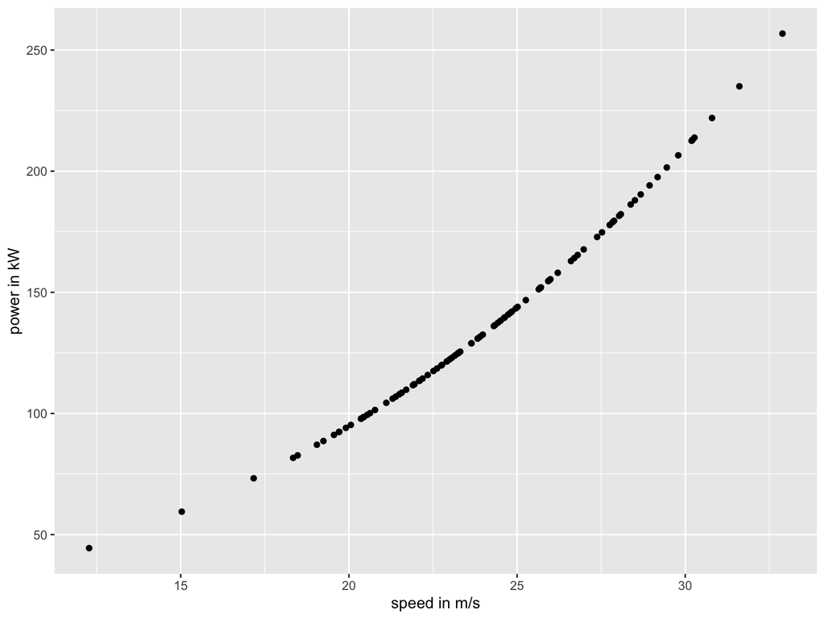

```r
# if you only have one input and everything else is the same, R is smart enough
# to create a set of outputs
results$power = autopower(V=speeds, A=25, m=20000)

# ALWAYS look at your results to make sure it make sense
ggplot(results, aes(speed, power/1000))+geom_point()+labs(x="speed in m/s", y="power in kW")
```

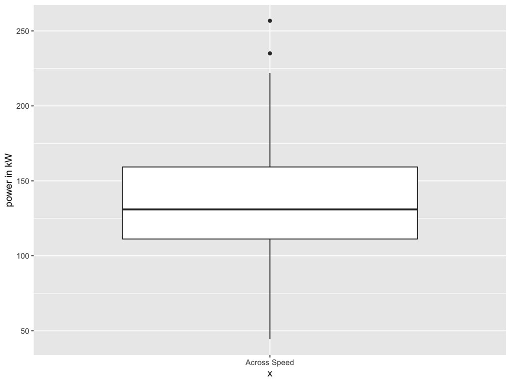

```r
ggplot(results, aes(x="Across Speed",y=power/1000))+geom_boxplot()+labs(y="power in kW")
```

# Looping (or repetition)

Looping - or repeating applying your function over multiple inputs is not always automatic

- more complex scenarios - number of different values is not the same for all inputs (e.g - you have 3 different speeds for 5 different cars (mass/Area))
- other programming languages

Lets start with the basics of how you do repetition in programming in general often called *looping*

```r
# simple example
# a = 0+1+2+3+4+5
a=0
for (i in 1:5) {
 a = a+i
}
a
```

```
## [1] 15
```

```r
#if you want to keep track of a for each iteration
# start with a data structure to hold the results - there will be 5 iterations

a = rep(x=0, times=5)
for (i in 1:5) {
 a[i] = a[i]+i
}
a
```

```
## [1] 1 2 3 4 5
```

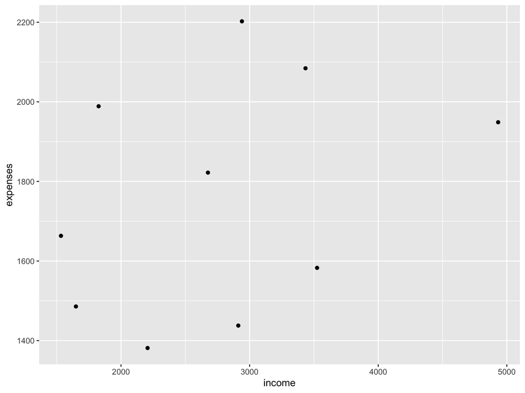

```r
# lets say we wanted to look income minus expenses for net income
# create some data for an example

income = runif(min=1000, max=5000, n=10)
expenses = rnorm(mean=1500, sd=500, n=10)
# it is possible that this approach could generate negative expenses
expenses = ifelse(expenses < 0, 0, expenses)
# normally we can just do
net = income-expenses

# lets make this a data frame for nice plotting
account = data.frame(income=income, expenses=expenses, net = net)
ggplot(account, aes(income, expenses))+geom_point()
```

```r
# lets add a year
account$year = seq(from=2000, length.out=nrow(account))


# we could have computed net income with a for loop
# sometimes we use NA to show we haven't computed it yet, so "initialize" as NA
netloop = rep(NA, times=10)
# alternatively we could add to account
account$netloop=NA
account
```

```
##      income expenses       net year netloop
## 1  1533.170 1663.290 -130.1194 2000      NA
## 2  3434.305 2084.356 1349.9493 2001      NA
## 3  2206.569 1381.367  825.2029 2002      NA
## 4  2675.851 1822.143  853.7082 2003      NA
## 5  2940.102 2202.328  737.7734 2004      NA
## 6  4932.325 1948.717 2983.6078 2005      NA
## 7  3524.503 1582.793 1941.7099 2006      NA
## 8  1649.366 1485.761  163.6050 2007      NA
## 9  2911.714 1437.746 1473.9681 2008      NA
## 10 1825.889 1988.860 -162.9713 2009      NA
```

```r
# note I can use any variable I want to as a counter -
# notice how I'm now using columns of the data frame
for (n in 1:10) {
  account$netloop[n] = account$income[n]-account$expenses[n]
}

# as expected net and netloop are the same :)
head(account)
```

```
##     income expenses       net year   netloop
## 1 1533.170 1663.290 -130.1194 2000 -130.1194
## 2 3434.305 2084.356 1349.9493 2001 1349.9493
## 3 2206.569 1381.367  825.2029 2002  825.2029
## 4 2675.851 1822.143  853.7082 2003  853.7082
## 5 2940.102 2202.328  737.7734 2004  737.7734
## 6 4932.325 1948.717 2983.6078 2005 2983.6078
```

# Why loop

what if we wanted to combine different rows and different columns?

for example, we wanted to carry forward from the previous year (info from a different row)

so carry forward net income is current years net income plus last years net

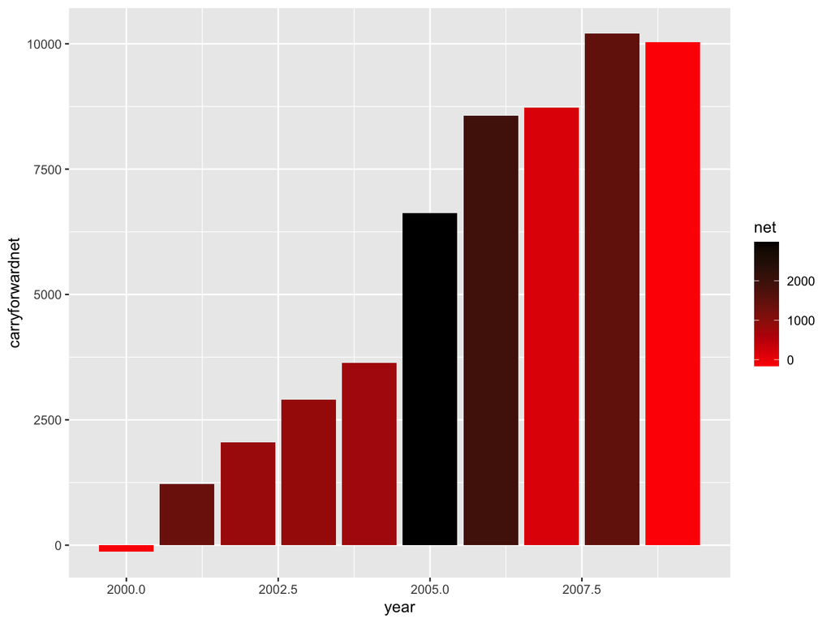

```r
View(account)

# note: we treat first year differently because we don't have carry forward
# initialize our column to zero, start counter (n) at 2 instead of 1
# make the first value equal to the net of first year

account$carryforwardnet = 0
account$carryforwardnet[1]=account$net[1]
# now loop - looking backward one year to get previous years carry forward
for (n in 2:10) {
  account$carryforwardnet[n] = account$net[n]+account$carryforwardnet[n-1]
}

# plot - and use color to show current years contribution as positive or negative
ggplot(account, aes(year, carryforwardnet, fill=net, group=year))+geom_col()+scale_fill_gradient(low="red", high="black")
```

```r
# another example - find the maximum speed from a set of speeds - lets make up an example
# by sampling from a random uniform distribution
speeds = runif(min=0, max=100, n=300)

maxspeed=0
for ( i  in 1:length(speeds)) {
  maxspeed = ifelse(speeds[i] > maxspeed, speeds[i], maxspeed)
}

maxspeed
```

```
## [1] 99.80228
```

```r
max(speeds)
```

```
## [1] 99.80228
```

# Another Example

Try this - make a random sample of fertilizer application, 10 values with mean of *5* and standard deviation of *0.5*

(user *rnorm* function in R to do this)

Lets imagine that annual yield of a crop can be estimated follows:

$$yield = 1.8*fertilizer^2 - 0.5*fertilizer + 0.3*TP$$

and TP is mean precipitation in cm

Use a *for* loop to compute the total yield after 10 years

- fertilizer is normally distributed with mean of 20 and standard deviation of 2
- TP is 20cm

Now create a function to that takes as input a single value for annual fertilizer and annual total precipitation and returns yield

Now modify your function so that it returns total yield if the user inputs a vector of fertilizer and a vector of precipitation

Check that function returns the same result as your original *for* loop Add some error checking and test

# Assignment

- Review looping.Rmd - its a long one
- recreate *possible_cars*, add an additional super light car with mass 5,000 kg, surface area 10m2
- provide 3 new estimates of power required that includes this super light car in the mix (one for each approach to repeating calculations)
- turn these 3 estimates in as Assignment 3 on Gauchospace; You should also try to recreate the graphs with a 4th car, you don’t need to turn in the graphs; we will go over in class